# Report

## Problem recognition

We want to be able to know what species a flower belongs to, according to 4 parameters concerning the sepal and the petal.

## Outlook of the data

```
##   Sepal.Length Sepal.Width Petal.Length Petal.Width Species
## 1          5.1         3.5          1.4         0.2  setosa
## 2          4.9         3.0          1.4         0.2  setosa
## 3          4.7         3.2          1.3         0.2  setosa
## 4          4.6         3.1          1.5         0.2  setosa
## 5          5.0         3.6          1.4         0.2  setosa
## 6          5.4         3.9          1.7         0.4  setosa
```

We notice that some data are missing.

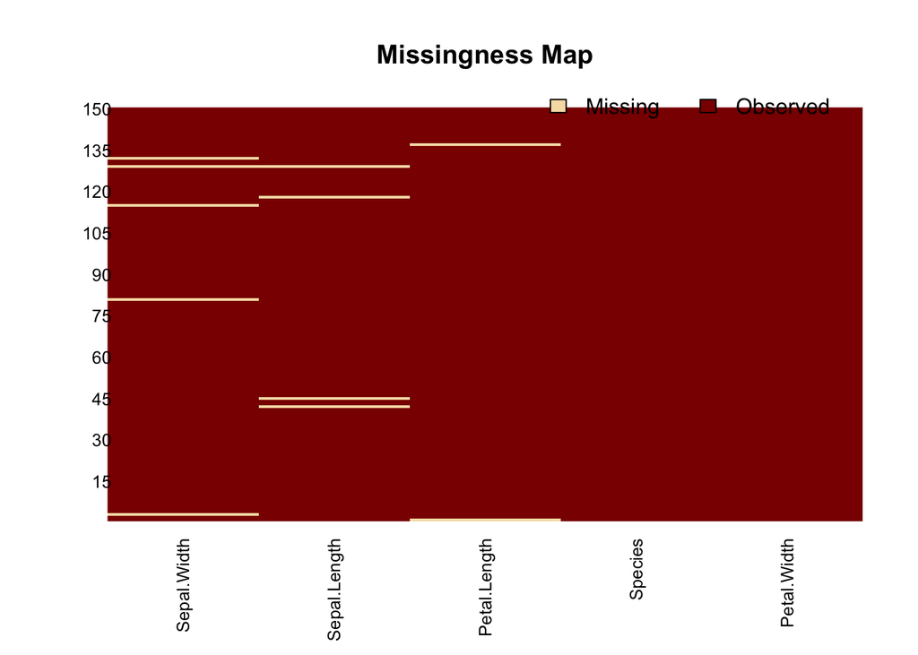

Thanks to the Amelia package, we can fill the missing data using the expectation–maximization (EM) algorithm.

Let’s split randomly the data into 2 parts : a training and a testing dataset. By default, createDataPartition does a stratified random split of the data.

```r
inTrain = createDataPartition(amelia1$Species, p = 2/3, list = FALSE)
dfTrain=amelia1[inTrain,]
dfTest=amelia1[-inTrain,]
```

## Exploration of the data

```
##   Sepal.Length    Sepal.Width     Petal.Length    Petal.Width
##  Min.   :4.400   Min.   :2.000   Min.   :1.000   Min.   :0.100
##  1st Qu.:5.100   1st Qu.:2.800   1st Qu.:1.500   1st Qu.:0.300
##  Median :5.800   Median :3.000   Median :4.300   Median :1.300
##  Mean   :5.866   Mean   :3.081   Mean   :3.781   Mean   :1.218
##  3rd Qu.:6.400   3rd Qu.:3.400   3rd Qu.:5.100   3rd Qu.:1.800
##  Max.   :7.900   Max.   :4.400   Max.   :6.900   Max.   :2.500
##        Species
##  setosa    :34
##  versicolor:34
##  virginica :34
##
##
##
```

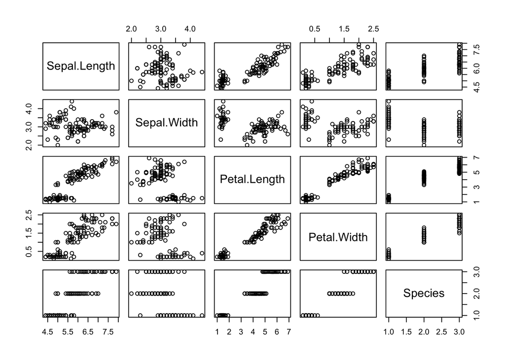

## Analysis

### Comparison using qqplot

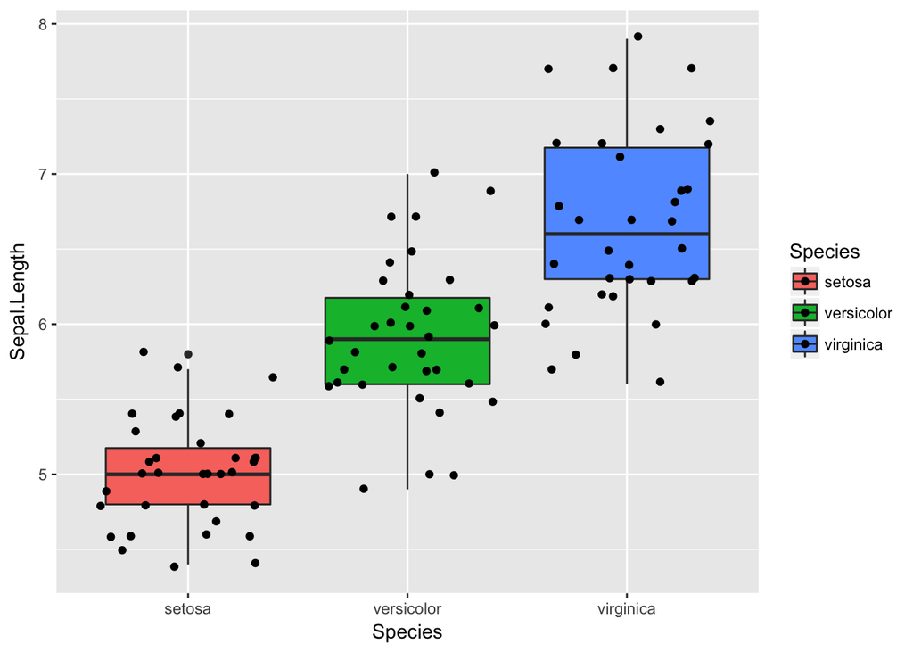

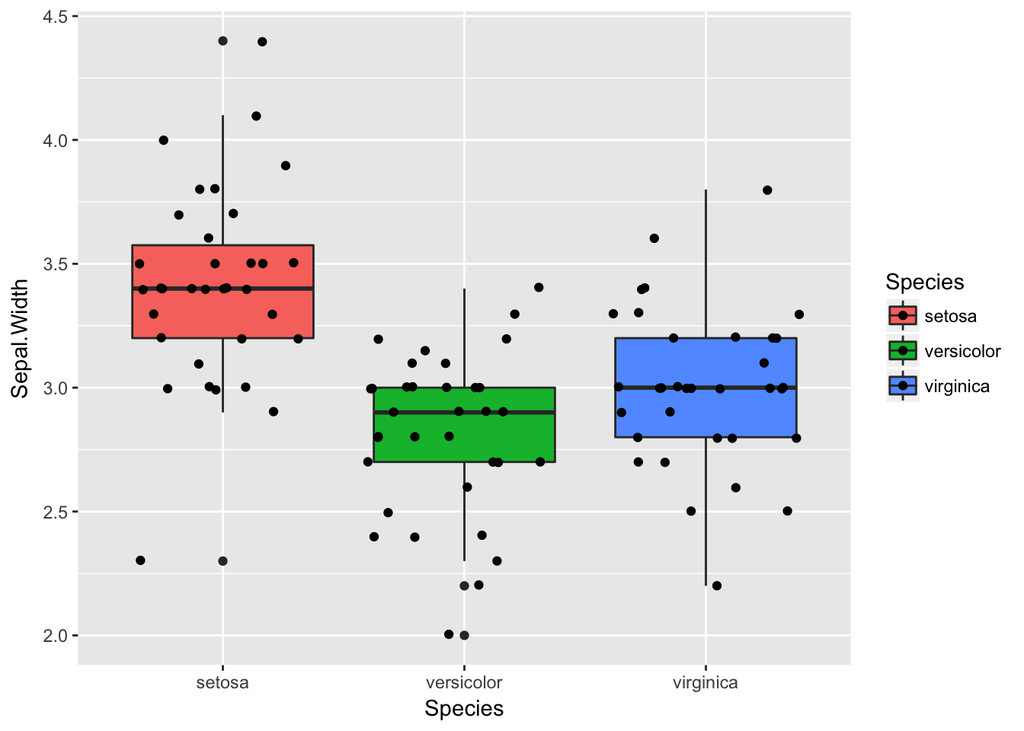

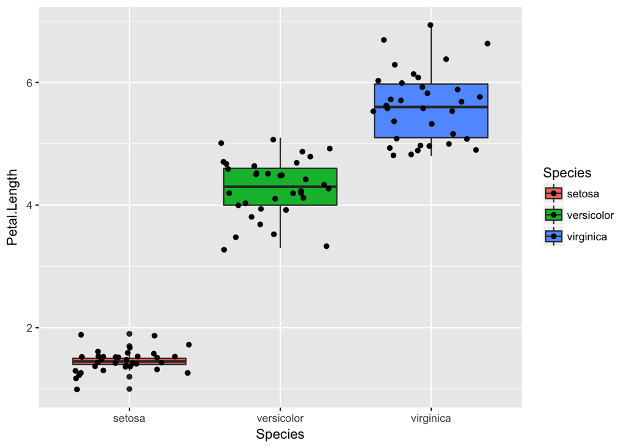

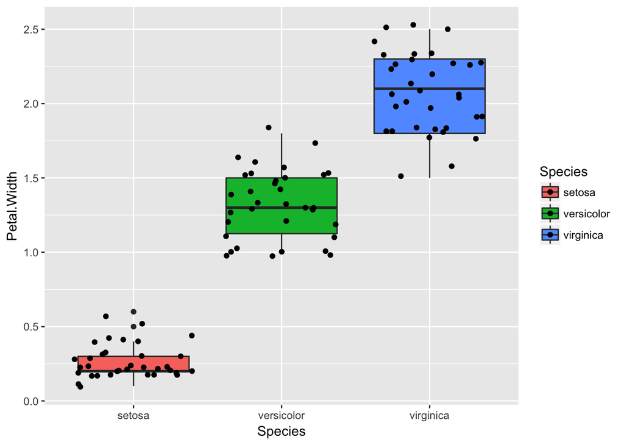

We can notice that the petal characteristics are more discriminant than the sepal ones. Indeed, the setosa is way different than the 2 others species.

### Looking for correlation

```
##              Sepal.Length Sepal.Width Petal.Length Petal.Width
## Sepal.Length         1.00       -0.10         0.88        0.83
## Sepal.Width         -0.10        1.00        -0.39       -0.32
## Petal.Length         0.88       -0.39         1.00        0.96
## Petal.Width          0.83       -0.32         0.96        1.00
##
## n= 102
##
##
## P
##              Sepal.Length Sepal.Width Petal.Length Petal.Width
## Sepal.Length              0.3265      0.0000       0.0000
## Sepal.Width  0.3265                   0.0000       0.0011
## Petal.Length 0.0000       0.0000                   0.0000
## Petal.Width  0.0000       0.0011      0.0000
```

It is clear that the petal width and the petal length are higly corrolated. The sepal length is corrolated with the petal length and width.

### Classification

We want to classify the data in 3 classes.

#### Decision Tree

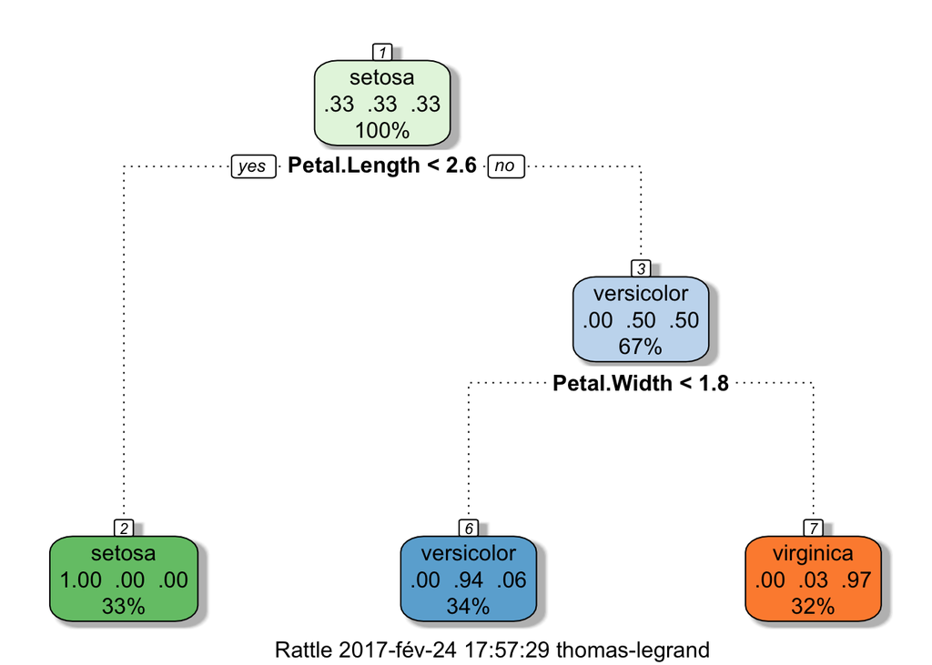

#### Naive Bayes Classifier

```r
bayes.fit<-naiveBayes(dfTrain[,1:4], dfTrain[,5])
bayes.model<-predict(bayes.fit, dfTest[,-5])
```

#### SVM

```
##
## Parameter tuning of 'svm':
##
## - sampling method: 10-fold cross validation
##
## - best parameters:
##  gamma cost
##    0.1    1
##
## - best performance: 0.05
```

```r
svm.model<-svm(Species~., data=dfTrain, gamma = 0.01, cost = 10)
svm.pred <- predict(svm.model, dfTest[,-5])
```

## Results

### Decision Tree

```
##
## tree.model   setosa versicolor virginica
##   setosa     100.00       0.00      0.00
##   versicolor   0.00     100.00     18.75
##   virginica    0.00       0.00     81.25
```

We can see that despite its simplicity the results are quite good. As we expected, the difficulty was about distinguishing versicolor and virginica.

### Naive Bayes Classifier

```
##
## bayes.model  setosa versicolor virginica
##   setosa        100          0         0
##   versicolor      0        100        25
##   virginica       0          0        75
```

### SVM

```
##             true
## pred         setosa versicolor virginica
##   setosa     100.00       0.00      0.00
##   versicolor   0.00      93.75     18.75
##   virginica    0.00       6.25     81.25
```